# **Customer Segmentation Analysis**

#### Q1. What is Customer Segmentation and why is it important from marketing perspective?

#### Answer 1:

Customer segmentation is a way of grouping or clustering clients based on shared demographic, psychographic and behavioural features such as age, gender, interests and spending habits. Occupation, gender, age, location, and marital status are all different examples of demographic traits. Social class, lifestyle, and personality traits are all psychographic features. Spending habits, consuming patterns, product/service usage, and previously acquired products are all behavioural traits.

The power of customer segmentation, could benefit in following ways:

1. Improved marketing campaigns: customer segmentation makes it possible to build tailored marketing messages to each particular segment. In fact, segmented campaigns have almost a 15% higher open rate than non-segmented ones.
2. Better offerings: knowing our customers allows to develop an offer for them so that it meets their particular needs to the best extent.
3. Greater return on sales: adjusting marketing efforts to company’s most successful customer segments can bring about an increase in revenue in the long run.
4. Increased loyalty and retention: personalization in every case matters. 80% of clients are more likely to do business with a brand that provides personalized experiences. So, customized content and individualized approach are what savours customer satisfaction and retention.
5. Untapped cross-selling and upselling opportunities: by segmenting existing and potential clients into groups, we realize what things they could be more interested in. It promotes the update of new products and services relevant to the targeted audience.

Conclusively, it is **important** because it aids in the identification of the most likely clients, makes it easier to manage and communicate with a specific audience. It boosts customer satisfaction, loyalty, and retention by improving customer relationships through better comprehending segment demands. Allows upselling and cross-selling opportunities by creating special offers for certain clients in order to persuade them to purchase more items. Customer segmentation aids in the identification of new customers by allowing for a better knowledge of the demands of various categories. **Each customer is valuable, and segmentation helps to create value for each one.**

## Import Libraries and Data

```python
# Import the appropriate Libraries
import pandas as pd # for dataframes
import matplotlib.pyplot as plt # for plotting graphs
import seaborn as sns # for plotting graphs
import datetime as dt
import numpy as np
import warnings
warnings.filterwarnings('ignore')
fig= plt.figure(figsize=(8,6))
```

```python
from google.colab import drive
drive.mount('/content/drive')
```

```python
# Load the dataset
data = pd.read_csv('/content/drive/MyDrive/Colab Notebooks/Sales_data.csv',encoding= 'ISO-8859-1')
# encoding='latin-1'
```

## Data Exploration

```python
data.info()
```

```
<class 'pandas.core.frame.DataFrame'>
RangeIndex: 541909 entries, 0 to 541908
Data columns (total 8 columns):
 #   Column       Non-Null Count   Dtype
---  ------       --------------   -----
 0   InvoiceNo    541909 non-null  object
 1   StockCode    541909 non-null  object
 2   Description  540455 non-null  object
 3   Quantity     541909 non-null  int64
 4   InvoiceDate  541909 non-null  object
 5   UnitPrice    541909 non-null  float64
 6   CustomerID   406829 non-null  float64
 7   Country      541909 non-null  object
dtypes: float64(2), int64(1), object(5)
memory usage: 33.1+ MB
```

```python
data.shape
```

```
(541909, 8)
```

```python
data.Description.value_counts()
```

```
WHITE HANGING HEART T-LIGHT HOLDER     2369
REGENCY CAKESTAND 3 TIER               2200
JUMBO BAG RED RETROSPOT                2159
PARTY BUNTING                          1727
LUNCH BAG RED RETROSPOT                1638
                                       ...
Missing                                   1
historic computer difference?....se       1
DUSTY PINK CHRISTMAS TREE 30CM            1
WRAP BLUE RUSSIAN FOLKART                 1
PINK BERTIE MOBILE PHONE CHARM            1
Name: Description, Length: 4223, dtype: int64
```

## Data Preprocessing

- Remove Null Values
- Remove Duplicate Values

```python
# Take all the rows where customer ID not equal to blank
data= data[pd.notnull(data['CustomerID'])]
```

```python
data.shape
```

```
(406829, 8)
```

```python
data.info()
```

```
<class 'pandas.core.frame.DataFrame'>
Int64Index: 406829 entries, 0 to 541908
Data columns (total 8 columns):
 #   Column       Non-Null Count   Dtype
---  ------       --------------   -----
 0   InvoiceNo    406829 non-null  object
 1   StockCode    406829 non-null  object
 2   Description  406829 non-null  object
 3   Quantity     406829 non-null  int64
 4   InvoiceDate  406829 non-null  object
 5   UnitPrice    406829 non-null  float64
 6   CustomerID   406829 non-null  float64
 7   Country      406829 non-null  object
dtypes: float64(2), int64(1), object(5)
memory usage: 27.9+ MB
```

```python
data.head()
```

|  | InvoiceNo | StockCode | Description | Quantity | InvoiceDate | UnitPrice | CustomerID | Country |
| --- | --- | --- | --- | --- | --- | --- | --- | --- |
| 0 | 536365 | 85123A | WHITE HANGING HEART T-LIGHT HOLDER | 6 | 12/1/2010 8:26 | 2.55 | 17850.0 | United Kingdom |
| 1 | 536365 | 71053 | WHITE METAL LANTERN | 6 | 12/1/2010 8:26 | 3.39 | 17850.0 | United Kingdom |
| 2 | 536365 | 84406B | CREAM CUPID HEARTS COAT HANGER | 8 | 12/1/2010 8:26 | 2.75 | 17850.0 | United Kingdom |
| 3 | 536365 | 84029G | KNITTED UNION FLAG HOT WATER BOTTLE | 6 | 12/1/2010 8:26 | 3.39 | 17850.0 | United Kingdom |
| 4 | 536365 | 84029E | RED WOOLLY HOTTIE WHITE HEART. | 6 | 12/1/2010 8:26 | 3.39 | 17850.0 | United Kingdom |

```python
# Removing duplicates
filtered_data=data[['Country','CustomerID']].drop_duplicates()
```

```python
filtered_data.shape
```

```
(4380, 2)
```

```python
filtered_data.head()
```

|  | Country | CustomerID |
| --- | --- | --- |
| 0 | United Kingdom | 17850.0 |
| 9 | United Kingdom | 13047.0 |
| 26 | France | 12583.0 |
| 46 | United Kingdom | 13748.0 |
| 65 | United Kingdom | 15100.0 |

```python
filtered_data.info()
```

```
<class 'pandas.core.frame.DataFrame'>
Int64Index: 4380 entries, 0 to 541768
Data columns (total 2 columns):
 #   Column      Non-Null Count  Dtype
---  ------      --------------  -----
 0   Country     4380 non-null   object
 1   CustomerID  4380 non-null   float64
dtypes: float64(1), object(1)
memory usage: 102.7+ KB
```

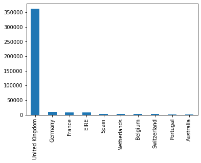

```python
data.Country.value_counts()[:10].plot(kind='bar')
```

## Data Insights

- Top 10 country customer data

```python
# Check the country wise distribution
data.Country.value_counts()
```

```
United Kingdom          361878
Germany                   9495
France                    8491
EIRE                      7485
Spain                     2533
Netherlands               2371
Belgium                   2069
Switzerland               1877
Portugal                  1480
Australia                 1259
Norway                    1086
Italy                      803
Channel Islands            758
Finland                    695
Cyprus                     622
Sweden                     462
Austria                    401
Denmark                    389
Japan                      358
Poland                     341
USA                        291
Israel                     250
Unspecified                244
Singapore                  229
Iceland                    182
Canada                     151
Greece                     146
Malta                      127
United Arab Emirates        68
European Community          61
RSA                         58
Lebanon                     45
Lithuania                   35
Brazil                      32
Czech Republic              30
Bahrain                     17
Saudi Arabia                10
Name: Country, dtype: int64
```

```python
filtered_data.Country.value_counts()[:10]
```

```
United Kingdom    3950
Germany             95
France              87
Spain               31
Belgium             25
Switzerland         21
Portugal            19
Italy               15
Finland             12
Austria             11
Name: Country, dtype: int64
```

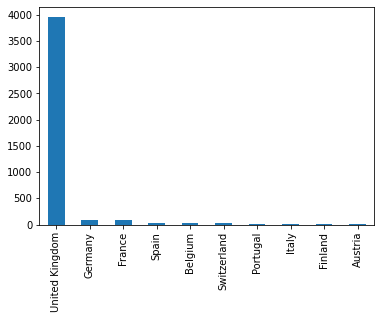

```python
# Plot the data
filtered_data.Country.value_counts()[:10].plot(kind='bar')
```

#### Q2. What do you observe?

#### Answer 2

UK has the highest number of customer base, more than 90% of data. In the unfiltered data set UK has orders in six figures and other countries has few thousands,or hundreds or tens. The filtered data is showing unique customers within the country. When we observe only 10 countries, UK has the maximum customers nearly 4000 whereas other countries have between 11 - 95. It will be difficult to compare customer from UK to any other country as the difference is huge and more likely imbalanced.

```python
## Filter data by the top most country
uk_data=data[data.Country=='United Kingdom']
```

```python
uk_data.describe()
```

|  | Quantity | UnitPrice | CustomerID |
| --- | --- | --- | --- |
| count | 361878.000000 | 361878.000000 | 361878.000000 |
| mean | 11.077029 | 3.256007 | 15547.871368 |
| std | 263.129266 | 70.654731 | 1594.402590 |
| min | -80995.000000 | 0.000000 | 12346.000000 |
| 25% | 2.000000 | 1.250000 | 14194.000000 |
| 50% | 4.000000 | 1.950000 | 15514.000000 |
| 75% | 12.000000 | 3.750000 | 16931.000000 |
| max | 80995.000000 | 38970.000000 | 18287.000000 |

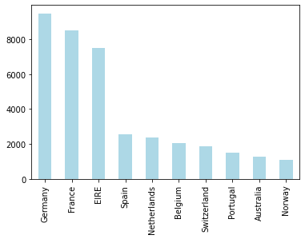

```python
#Data from other Countries
other_countries=data[data.Country!='United Kingdom']
other_countries.Country.value_counts()[:10].plot(kind='bar',color="lightblue")
```

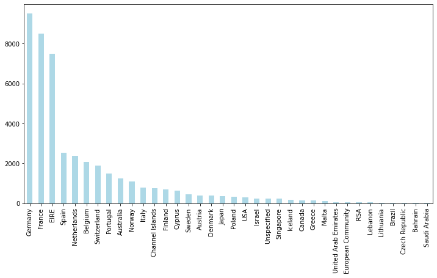

```python
fig= plt.figure(figsize=(12,6))
other_countries.Country.value_counts().plot(kind='bar',color="lightblue")
```

```python
# Calculate Total Price within other countries
other_countries['TotalPrice'] = other_countries['Quantity'] * other_countries['UnitPrice']
other_countries['TotalPrice'].max()
```

```
4992.0
```

#### Q3. What do you observe? Which column needs special attention?

#### Answer 3

There is ambigiuous data in **Quantity** Minimum is -ve and Maximum has +ve values which is same figure, the **minimum value is -80995** which is unrealistic unless these are refunds. Cust ID binds us to customers, the minimum Unit Price is 0.00 which should also be not the case. Therefore **Quantity and Unit Price** needs special attention hence should be addressed.

```python
uk_data = uk_data[(uk_data['Quantity'] > 0)]
```

```python
uk_data.info()
```

```
<class 'pandas.core.frame.DataFrame'>
Int64Index: 354345 entries, 0 to 541893
Data columns (total 8 columns):
 #   Column       Non-Null Count   Dtype
---  ------       --------------   -----
 0   InvoiceNo    354345 non-null  object
 1   StockCode    354345 non-null  object
 2   Description  354345 non-null  object
 3   Quantity     354345 non-null  int64
 4   InvoiceDate  354345 non-null  object
 5   UnitPrice    354345 non-null  float64
 6   CustomerID   354345 non-null  float64
 7   Country      354345 non-null  object
dtypes: float64(2), int64(1), object(5)
memory usage: 24.3+ MB
```

```python
uk_data.head()
```

|  | InvoiceNo | StockCode | Description | Quantity | InvoiceDate | UnitPrice | CustomerID | Country |
| --- | --- | --- | --- | --- | --- | --- | --- | --- |
| 0 | 536365 | 85123A | WHITE HANGING HEART T-LIGHT HOLDER | 6 | 12/1/2010 8:26 | 2.55 | 17850.0 | United Kingdom |
| 1 | 536365 | 71053 | WHITE METAL LANTERN | 6 | 12/1/2010 8:26 | 3.39 | 17850.0 | United Kingdom |
| 2 | 536365 | 84406B | CREAM CUPID HEARTS COAT HANGER | 8 | 12/1/2010 8:26 | 2.75 | 17850.0 | United Kingdom |
| 3 | 536365 | 84029G | KNITTED UNION FLAG HOT WATER BOTTLE | 6 | 12/1/2010 8:26 | 3.39 | 17850.0 | United Kingdom |
| 4 | 536365 | 84029E | RED WOOLLY HOTTIE WHITE HEART. | 6 | 12/1/2010 8:26 | 3.39 | 17850.0 | United Kingdom |

```python
# Filter the required columns only
uk_data=uk_data[['CustomerID','InvoiceDate','InvoiceNo','Quantity','UnitPrice']]
```

```python
# Calculate Total Price
uk_data['TotalPrice'] = uk_data['Quantity'] * uk_data['UnitPrice']
```

```python
uk_data['TotalPrice'].max()
```

```
168469.6
```

```python
uk_data['TotalPrice'].describe()
```

```
count    354345.000000
mean         20.625073
std         326.033014
min           0.000000
25%           4.160000
50%          10.200000
75%          17.700000
max      168469.600000
Name: TotalPrice, dtype: float64
```

```python
#print data after adding total_price
uk_data.head()
```

|  | CustomerID | InvoiceDate | InvoiceNo | Quantity | UnitPrice | TotalPrice |
| --- | --- | --- | --- | --- | --- | --- |
| 0 | 17850.0 | 12/1/2010 8:26 | 536365 | 6 | 2.55 | 15.30 |
| 1 | 17850.0 | 12/1/2010 8:26 | 536365 | 6 | 3.39 | 20.34 |
| 2 | 17850.0 | 12/1/2010 8:26 | 536365 | 8 | 2.75 | 22.00 |
| 3 | 17850.0 | 12/1/2010 8:26 | 536365 | 6 | 3.39 | 20.34 |
| 4 | 17850.0 | 12/1/2010 8:26 | 536365 | 6 | 3.39 | 20.34 |

## Time frame of data

```python
# Check Min and Max dates
print(uk_data['InvoiceDate'].min())
print(uk_data['InvoiceDate'].max())
```

```
1/10/2011 10:32
9/9/2011 9:52
```

#### Q4. Comment on the above results.

#### Answer 4

Data is segmented for UK and

## Perform RFM Analysis

- For Recency, Calculate the number of days between present date and date of last purchase for each customer.
- For Frequency, Calculate the number of orders for each customer.
- For Monetary, Calculate sum of purchase price for each customer

```python
# Store a date as a reference point for recency calculations
PRESENT = dt.datetime(2011, 12, 10)

# Convert date to datetime format
uk_data['InvoiceDate'] = pd.to_datetime(uk_data['InvoiceDate'])
```

```python
# Check Min and Max dates
print(uk_data['InvoiceDate'].min())
print(uk_data['InvoiceDate'].max())
```

```
2010-12-01 08:26:00
2011-12-09 12:49:00
```

```python
uk_data['InvoiceDate'].head()
```

```
0   2010-12-01 08:26:00
1   2010-12-01 08:26:00
2   2010-12-01 08:26:00
3   2010-12-01 08:26:00
4   2010-12-01 08:26:00
Name: InvoiceDate, dtype: datetime64[ns]
```

```python
uk_data['InvoiceNo'].value_counts().head()
```

```
576339    542
579196    533
580727    529
578270    442
573576    435
Name: InvoiceNo, dtype: int64
```

#### Q5. Comment on the above results

#### Answer 5

There are two main observations

- In first two code snippets we see that after changing date in the correct format we have data from the 1st Dec 2010 (min) to 9th December 2011 (max) (approx 1 year).
- The the later two code snippets we observe that we have multiple records with same date and time stamp and invoice number has duplicate values, however invoice no are expected to be unique for an order.
- The invoice number value counts shows the different Invoice numbers with its frequency i.e. how many times that invoice number is dulpicated. It could be concluded that all the products ordered in single order have the same invoice number. The number of products bought at a time is high with numbers like 542, 435 etc
- It would also mean that we have fewer customers but they are buying moderately
- We could study number of orders per customer by grouping records.

```python
#check number of orders
len(uk_data['InvoiceNo'].value_counts())
```

```
16649
```

```python
#check number of customers
len(uk_data['CustomerID'].value_counts())
```

```
3921
```

```python
orders = uk_data.groupby(['InvoiceNo', 'InvoiceDate', 'CustomerID']).agg({'TotalPrice': lambda x: x.sum()}).reset_index()
orders.head()
```

|  | InvoiceNo | InvoiceDate | CustomerID | TotalPrice |
| --- | --- | --- | --- | --- |
| 0 | 536365 | 2010-12-01 08:26:00 | 17850.0 | 139.12 |
| 1 | 536366 | 2010-12-01 08:28:00 | 17850.0 | 22.20 |
| 2 | 536367 | 2010-12-01 08:34:00 | 13047.0 | 278.73 |
| 3 | 536368 | 2010-12-01 08:34:00 | 13047.0 | 70.05 |
| 4 | 536369 | 2010-12-01 08:35:00 | 13047.0 | 17.85 |

```python
#calculate rfm - this one is counting each transaction as frequency
rfm= uk_data.groupby('CustomerID').agg({'InvoiceDate': lambda date: (PRESENT - date.max()).days,'InvoiceNo': lambda num: len(num),'TotalPrice': lambda price: price.sum()})
```

```python
rfm
```

| CustomerID | InvoiceDate | InvoiceNo | TotalPrice |
| --- | --- | --- | --- |
| 12346.0 | 325 | 1 | 77183.60 |
| 12747.0 | 2 | 103 | 4196.01 |
| 12748.0 | 0 | 4596 | 33719.73 |
| 12749.0 | 3 | 199 | 4090.88 |
| 12820.0 | 3 | 59 | 942.34 |
| ... | ... | ... | ... |
| 18280.0 | 277 | 10 | 180.60 |
| 18281.0 | 180 | 7 | 80.82 |
| 18282.0 | 7 | 12 | 178.05 |
| 18283.0 | 3 | 756 | 2094.88 |
| 18287.0 | 42 | 70 | 1837.28 |

3921 rows × 3 columns

```python
rfm.describe()
```

|  | InvoiceDate | InvoiceNo | TotalPrice |
| --- | --- | --- | --- |
| count | 3921.000000 | 3921.000000 | 3921.000000 |
| mean | 91.722265 | 90.371079 | 1863.910113 |
| std | 99.528532 | 217.796155 | 7481.922217 |
| min | 0.000000 | 1.000000 | 0.000000 |
| 25% | 17.000000 | 17.000000 | 300.040000 |
| 50% | 50.000000 | 41.000000 | 651.820000 |
| 75% | 142.000000 | 99.000000 | 1575.890000 |
| max | 373.000000 | 7847.000000 | 259657.300000 |

```python
# Rename the columns
rfm.columns=['monetary','frequency','recency']
```

```python
rfm['recency'] = rfm['recency'].astype(int)
rfm['monetary'] = rfm['monetary'].astype(int)
```

```python
rfm.head()
```

| CustomerID | monetary | frequency | recency |
| --- | --- | --- | --- |
| 12346.0 | 325 | 1 | 77183 |
| 12747.0 | 2 | 103 | 4196 |
| 12748.0 | 0 | 4596 | 33719 |
| 12749.0 | 3 | 199 | 4090 |
| 12820.0 | 3 | 59 | 942 |

#### Q6. What is wrong with this table think ??

#### Answer 6

In the table, for customer ID 12748, it shows monetary value as '0' and respective frequency is 4596 which is realistically impossible. The column have been mislabelled in the above table. While the column InvoiceDate must be recency it has been mislabelled as monetary. TotalPrice must be monetary but has been mislabelled as recency.Apparently, Total Price should be monetary and the days difference from present should be recency, hence the column headers need relabelling. Also the difference between certain dates is not correct hence number of the days are incorrect , further each transaction has been counted as a frequency whereas one order should be counted as a frequency.

```python
# Change the column names
rfm.columns=['recency','frequency','monetary']
```

#### Recalculated RFM as needed

```python
# add a column with total days since last order
uk_data['days'] = (PRESENT - uk_data['InvoiceDate']).dt.days
uk_data.head()
```

|  | CustomerID | InvoiceDate | InvoiceNo | Quantity | UnitPrice | TotalPrice | days |
| --- | --- | --- | --- | --- | --- | --- | --- |
| 0 | 17850.0 | 2010-12-01 08:26:00 | 536365 | 6 | 2.55 | 15.30 | 373 |
| 1 | 17850.0 | 2010-12-01 08:26:00 | 536365 | 6 | 3.39 | 20.34 | 373 |
| 2 | 17850.0 | 2010-12-01 08:26:00 | 536365 | 8 | 2.75 | 22.00 | 373 |
| 3 | 17850.0 | 2010-12-01 08:26:00 | 536365 | 6 | 3.39 | 20.34 | 373 |
| 4 | 17850.0 | 2010-12-01 08:26:00 | 536365 | 6 | 3.39 | 20.34 | 373 |

```python
#calculate rfm - this one is counting each unique invoice no's as a frequency
rfm1= uk_data.groupby('CustomerID').agg({'days': lambda Recency: Recency.min(), 'InvoiceNo': lambda Frequency: len(Frequency.unique()), 'TotalPrice': lambda Monetary: Monetary.sum()})
rfm1.columns=['recency','frequency','monetary']
```

```python
rfm1
```

| CustomerID | recency | frequency | monetary |
| --- | --- | --- | --- |
| 12346.0 | 325 | 1 | 77183.60 |
| 12747.0 | 2 | 11 | 4196.01 |
| 12748.0 | 0 | 210 | 33719.73 |
| 12749.0 | 3 | 5 | 4090.88 |
| 12820.0 | 3 | 4 | 942.34 |
| ... | ... | ... | ... |
| 18280.0 | 277 | 1 | 180.60 |
| 18281.0 | 180 | 1 | 80.82 |
| 18282.0 | 7 | 2 | 178.05 |
| 18283.0 | 3 | 16 | 2094.88 |
| 18287.0 | 42 | 3 | 1837.28 |

3921 rows × 3 columns

## Create Visuals

- Histogram for Recency Data
- Histogram for Frequency Data
- Histogram for Monetary Data

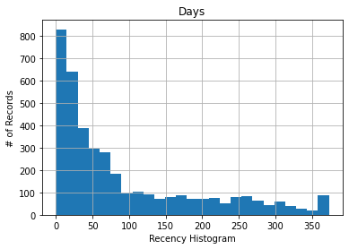

```python
# Histogram for Recency Data (UK)
rfm.hist(column='recency', bins=25)
plt.xlabel('Recency Histogram')
plt.ylabel('# of Records')
plt.title('Days')
```

#### Q7. What does this above chart tell ?

#### Answer 7:

The above graph shows the distribution of recency data for United Kingdom with the **most recent puchases reoccurring within 0-50 days**, there is around 100 transactions that range after 100 to 370 days.

- The above graph shows that consumers who purchased within the last two months (up to 50 days) are more numerous, and we also have some lost customers (customers who have not returned in over a year are referred to as "lost customers.")
- Customers who had just visited would make more revenue than those who had visited in the past.
- Our attention should be on the most recent consumers rather than those who visited a long time ago, because the most current customers will provide the majority of recent sales.

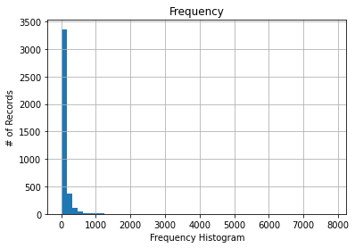

```python
# Histogram for Frequency Data (UK)
rfm.hist(column='frequency', bins=50)
plt.xlabel('Frequency Histogram')
plt.ylabel('# of Records')
plt.title('Frequency')
```

#### Q8. What does this above chart tell ?

#### Answer 8:

- Frequency is how many times did the customer purchase.In our dataset we are looking at how many products did they buy
- The highest frequency seems to between **0-50** with puchases over 3000. In other words nearly 3400 clients have a relatively low frequency of purchase, meaning they don't buy very often.
- There are only a handful consumers who have a frequency of more than 1000. The frequency rate of their shopping is 1/20th of 1000.

##### Recreating the Visual for Frequency

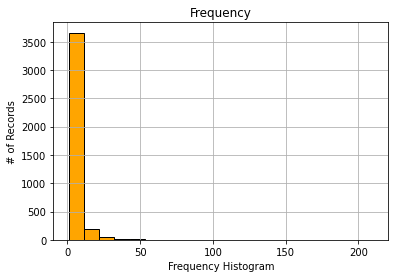

```python
# Histogram for frequency Data (UK)
rfm1.hist(column='frequency', bins=20,color='orange', edgecolor='black')
plt.xlabel('Frequency Histogram')
plt.ylabel('# of Records')
plt.title('Frequency')
```

**Frequency is very low.** Majority have bought only 10 times, bearly 2% have bought 20 times and a very few have bought more than 30 times.

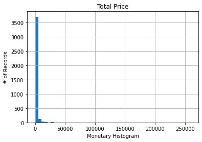

```python
# Histogram for Monetary Data (UK)
rfm.hist(column='monetary', bins=50)
plt.xlabel('Monetary Histogram')
plt.ylabel('# of Records')
plt.title('Total Price')
```

##### Their is ambiguity due to outliers and scarce wide distribution. It’s a not clear what's the customer's spending pattern. However, we can approximate that 3600 people spent one tenth of a monetary value of 50000.

```python
rfm.sort_values(by=['monetary'], inplace=True)
rfm.head()
```

| CustomerID | recency | frequency | monetary |
| --- | --- | --- | --- |
| 13256.0 | 14 | 1 | 0 |
| 16738.0 | 297 | 1 | 3 |
| 16454.0 | 44 | 2 | 6 |
| 14792.0 | 63 | 2 | 6 |
| 17956.0 | 249 | 1 | 12 |

```python
rfm = rfm[rfm.monetary <10000]
```

```python
rfm.tail(100)
```

| CustomerID | recency | frequency | monetary |
| --- | --- | --- | --- |
| 14049.0 | 16 | 488 | 5681 |
| 14110.0 | 3 | 156 | 5683 |
| 13468.0 | 1 | 302 | 5704 |
| 16553.0 | 163 | 84 | 5719 |
| 13178.0 | 26 | 265 | 5725 |
| ... | ... | ... | ... |
| 14733.0 | 16 | 202 | 9585 |
| 13458.0 | 7 | 382 | 9646 |
| 15078.0 | 7 | 440 | 9743 |
| 13199.0 | 3 | 119 | 9817 |
| 13001.0 | 4 | 339 | 9818 |

100 rows × 3 columns

### Histogram for Monetary Data (UK)

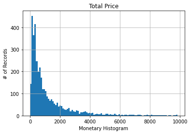

```python
#Histogram for Monetary Data (UK)
rfm.hist(column='monetary', bins=100)
plt.xlabel('Monetary Histogram')
plt.ylabel('# of Records')
plt.title('Total Price')
```

#### Q9. What does this above chart tell ?

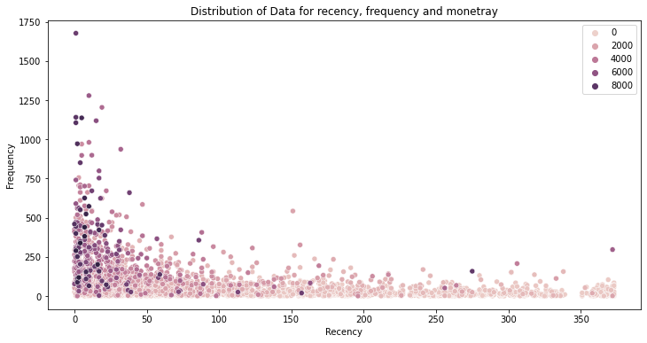

```python
#Create a scatter plot for the distribution of all three variables
fig= plt.figure(figsize=(12,6))
plt.xlabel("Recency")
plt.ylabel("Frequency")
plt.title("Distribution of Data for recency, frequency and monetray")
sns.scatterplot(data = rfm, x =rfm['recency'], y = rfm['frequency'], hue=rfm.monetary.tolist())
```

```python
# Calculate Z scores to normalize the data
from scipy import stats
import numpy as np
z = np.abs(stats.zscore(rfm))
print(z)
```

```
[[0.79548532 0.66779943 0.80336162]
 [2.04159154 0.66779943 0.80133672]
 [0.49473512 0.65921664 0.79931182]
 ...
 [0.86566036 3.10004395 5.77283257]
 [0.90576039 0.34496941 5.82278006]
 [0.89573538 2.23318249 5.82345502]]
```

```python
# Save the cleaned file
#rfm.to_csv('rfm.csv')
```

```python
#np.abs(stats.zscore(rfm1)).to_csv('rfm1.csv')
#rfm.describe
```

## Calcualte the RFM Score

```python
# Use quintiles to to make 5 equal parts based on the available values. Each quintiles contains 20% of the population.
quintiles = rfm[['recency', 'frequency', 'monetary']].quantile([.2, .4, .6, .8]).to_dict()
quintiles
```

```
{'frequency': {0.2: 13.0, 0.4: 28.0, 0.6: 55.0, 0.8: 115.0},
 'monetary': {0.2: 236.0, 0.4: 450.0, 0.6: 854.0, 0.8: 1822.0},
 'recency': {0.2: 15.0, 0.4: 33.0, 0.6: 72.0, 0.8: 182.0}}
```

```python
# Define functions to assign ranks from 1 to 5.
# A lower Recency value is better and higher Frequency and Monetary values are better.
# We will have to write two separate functions
```

```python
def r_score(x):
    if x <= quintiles['recency'][.2]:
        return 5
    elif x <= quintiles['recency'][.4]:
        return 4
    elif x <= quintiles['recency'][.6]:
        return 3
    elif x <= quintiles['recency'][.8]:
        return 2
    else:
        return 1

def fm_score(x, c):
    if x <= quintiles[c][.2]:
        return 1
    elif x <= quintiles[c][.4]:
        return 2
    elif x <= quintiles[c][.6]:
        return 3
    elif x <= quintiles[c][.8]:
        return 4
    else:
        return 5
```

```python
# Calculate RFM score for each customer
rfm['R'] = rfm['recency'].apply(lambda x: r_score(x))
rfm['F'] = rfm['frequency'].apply(lambda x: fm_score(x, 'frequency'))
rfm['M'] = rfm['monetary'].apply(lambda x: fm_score(x, 'monetary'))
```

```python
# Combine the scores
rfm['RFM Score'] = rfm['R'].map(str) + rfm['F'].map(str) + rfm['M'].map(str)
rfm.head()
```

| CustomerID | recency | frequency | monetary | R | F | M | RFM Score |
| --- | --- | --- | --- | --- | --- | --- | --- |
| 13256.0 | 14 | 1 | 0 | 5 | 1 | 1 | 511 |
| 16738.0 | 297 | 1 | 3 | 1 | 1 | 1 | 111 |
| 16454.0 | 44 | 2 | 6 | 3 | 1 | 1 | 311 |
| 14792.0 | 63 | 2 | 6 | 3 | 1 | 1 | 311 |
| 17956.0 | 249 | 1 | 12 | 1 | 1 | 1 | 111 |

```python
# Create the customer segments based on your knowledge.
# Create 6 segments based on R and F scores

segments = {
    '[1-2][1-4]': 'At risk',
    '[1-2]5': 'Can\'t loose',
    '3[1-3]': 'Needs Attention',
    '[3-4][4-5]': 'Loyal Customers',
    '[4-5]1': 'New customers',
    '[4-5][2-5]': 'Champions'

}

rfm['Segment'] = rfm['R'].map(str) + rfm['F'].map(str)
rfm['Segment'] = rfm['Segment'].replace(segments, regex=True)
rfm.head()
```

| CustomerID | recency | frequency | monetary | R | F | M | RFM Score | Segment |
| --- | --- | --- | --- | --- | --- | --- | --- | --- |
| 13256.0 | 14 | 1 | 0 | 5 | 1 | 1 | 511 | New customers |
| 16738.0 | 297 | 1 | 3 | 1 | 1 | 1 | 111 | At risk |
| 16454.0 | 44 | 2 | 6 | 3 | 1 | 1 | 311 | Needs Attention |
| 14792.0 | 63 | 2 | 6 | 3 | 1 | 1 | 311 | Needs Attention |
| 17956.0 | 249 | 1 | 12 | 1 | 1 | 1 | 111 | At risk |

```python
# count the number of customers in each segment
segments_counts = rfm['Segment'].value_counts().sort_values(ascending=True)

segments_counts
```

```
Can't loose          77
New customers       147
Needs Attention     477
Loyal Customers     695
Champions           989
At risk            1451
Name: Segment, dtype: int64
```

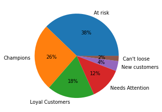

```python
plt.pie(rfm.Segment.value_counts(),
        labels=rfm.Segment.value_counts().index,
        autopct='%.0f%%')
plt.show()
```

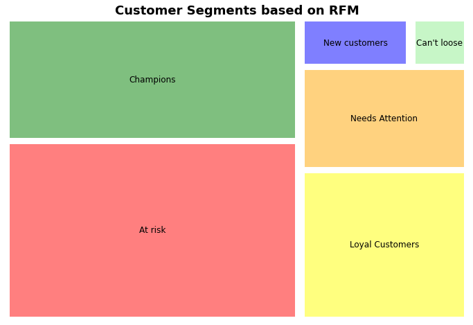

```python
#Create our RFM Segment plot and resize it.
!pip install squarify
import squarify
fig = plt.gcf()
ax = fig.add_subplot()
fig.set_size_inches(12, 8)
ax=squarify.plot(rfm.Segment.value_counts(),label=rfm.Segment.value_counts().index, pad = True, color=['red','green','yellow','orange','blue','lightgreen'],
                                                                                                       bar_kwargs={'alpha':0.5},text_kwargs={'fontsize':12},ax=ax)
plt.title("Customer Segments based on RFM",fontsize=18,fontweight="bold")
plt.axis('off')
plt.show()
#ax = squarify.plot(countryPop, color=colors, label=labels, ax=ax, bar_kwargs={'alpha':.7}, text_kwargs={'fontsize':10})
```

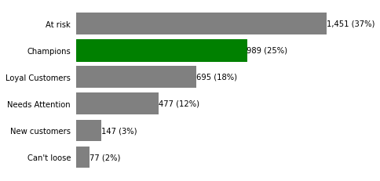

```python
# Distribution of Segments
fig, ax = plt.subplots()

bars = ax.barh(range(len(segments_counts)),
              segments_counts,
              color='gray')
ax.set_frame_on(False)
ax.tick_params(left=False,
               bottom=False,
               labelbottom=False)
ax.set_yticks(range(len(segments_counts)))
ax.set_yticklabels(segments_counts.index)

for i, bar in enumerate(bars):
        value = bar.get_width()
        if segments_counts.index[i] in ['Champions', 'Loyal customers']:
            bar.set_color('green')
        ax.text(value,
                bar.get_y() + bar.get_height()/2,
                '{:,} ({:}%)'.format(int(value),
                                   int(value*100/segments_counts.sum())),
                va='center',
                ha='left'
               )

plt.show()
```

#### Q11. Who are the best customers?

#### Answer 11

Customers with high RFM score. Champions and loyal customers are the best customers because recency ranges from 3-5 and have monetary score is ranged between 3-5 and frequency moderate as compared to other customers. Can't loose are perfect as they require minimal efforts. Chmapions drive the constant revenue.

```python
rfm[rfm['RFM Score']=='555'].sort_values('monetary', ascending=False).head()
```

| CustomerID | recency | frequency | monetary | R | F | M | RFM Score | Segment |
| --- | --- | --- | --- | --- | --- | --- | --- | --- |
| 13001.0 | 4 | 339 | 9818 | 5 | 5 | 5 | 555 | Champions |
| 13199.0 | 3 | 119 | 9817 | 5 | 5 | 5 | 555 | Champions |
| 15078.0 | 7 | 440 | 9743 | 5 | 5 | 5 | 555 | Champions |
| 13458.0 | 7 | 382 | 9646 | 5 | 5 | 5 | 555 | Champions |
| 16523.0 | 1 | 290 | 9418 | 5 | 5 | 5 | 555 | Champions |

#### Q12. Which customers are likely to churn?

#### Answer 12.

Customers with low recency and frequency score are most likely to churn, we had 37% customers at risk. The next segment after 'at risk' is 'need attention' and are more likely to Churn follwoed by the probability of can't loose. They have low RF score but high monetary score as tend to sepnd more when they buy.

```python
#Customers who's recency value is low

rfm[rfm['R'] <= 1 ].sort_values('monetary', ascending=False).head()
```

| CustomerID | recency | frequency | monetary | R | F | M | RFM Score | Segment |
| --- | --- | --- | --- | --- | --- | --- | --- | --- |
| 13093.0 | 275 | 159 | 7832 | 1 | 5 | 5 | 155 | Can't loose |
| 17850.0 | 372 | 297 | 5391 | 1 | 5 | 5 | 155 | Can't loose |
| 15032.0 | 256 | 52 | 4959 | 1 | 3 | 5 | 135 | At risk |
| 15808.0 | 306 | 208 | 3734 | 1 | 5 | 5 | 155 | Can't loose |
| 17230.0 | 264 | 69 | 3638 | 1 | 4 | 5 | 145 | At risk |

#### Q13. Which customers we are going to loose?

#### Answer 13.

Customers who's recency, frequency and monetary values are all low are the customers we are likely to loose. The RFM value of 111. This with overlap with the customers who all are at risk because of low recency score. They have not made recent purchase hence, they might leave.

```python
#Customers who's recency, frequency and monetary values are low

rfm[rfm['RFM Score']=='111'].sort_values('recency',ascending=False).head()
```

| CustomerID | recency | frequency | monetary | R | F | M | RFM Score | Segment |
| --- | --- | --- | --- | --- | --- | --- | --- | --- |
| 14237.0 | 373 | 9 | 161 | 1 | 1 | 1 | 111 | At risk |
| 17643.0 | 373 | 8 | 101 | 1 | 1 | 1 | 111 | At risk |
| 15350.0 | 373 | 5 | 115 | 1 | 1 | 1 | 111 | At risk |
| 13747.0 | 373 | 1 | 79 | 1 | 1 | 1 | 111 | At risk |
| 15070.0 | 372 | 1 | 106 | 1 | 1 | 1 | 111 | At risk |

#### Q14. Who are the loyal customers?

#### Answer 14.

Customers with high frequency value are the loyal customers. The F score of more than 3. Champions and Loyal Customers are the two segments that are loyal customers.

```python
#Customers with high frequency value

rfm[rfm['F'] >= 3 ].sort_values('monetary', ascending=False).head()
```

| CustomerID | recency | frequency | monetary | R | F | M | RFM Score | Segment |
| --- | --- | --- | --- | --- | --- | --- | --- | --- |
| 13001.0 | 4 | 339 | 9818 | 5 | 5 | 5 | 555 | Champions |
| 13199.0 | 3 | 119 | 9817 | 5 | 5 | 5 | 555 | Champions |
| 15078.0 | 7 | 440 | 9743 | 5 | 5 | 5 | 555 | Champions |
| 13458.0 | 7 | 382 | 9646 | 5 | 5 | 5 | 555 | Champions |
| 14733.0 | 16 | 202 | 9585 | 4 | 5 | 5 | 455 | Loyal Customers |

## Q15 Calculate RFM scores using 4 quintiles instead of 5 and answer all the questions again

- Make sure you give proper names to the segments. Please create 4 segments based on R and F scores instead of 6

```python
# Using quintiles to make 4 equal parts based on the available values. Each quintile contains 25% of the population.
quintiles_1 = rfm[['recency', 'frequency', 'monetary']].quantile([.25, .5, .75]).to_dict()
quintiles_1
```

```
{'frequency': {0.25: 16.0, 0.5: 40.0, 0.75: 95.0},
 'monetary': {0.25: 293.0, 0.5: 628.0, 0.75: 1476.0},
 'recency': {0.25: 18.0, 0.5: 51.5, 0.75: 147.0}}
```

```python
#Define functions to assign ranks from 1 to 4.
# A lower Recency value is better and higher Frequency and Monetary values are better, write two separate functions
def rscore(x):
    if x <= quintiles_1['recency'][.25]:
        return 4 #Customer is more engaged
    elif x <= quintiles_1['recency'][.50]:
        return 3
    elif x <= quintiles_1['recency'][.75]:
        return 2
    else:
        return 1

def fmscore(x, c):
    if x <= quintiles_1[c][.25]:
        return 1
    elif x <= quintiles_1[c][.50]:
        return 2
    elif x <= quintiles_1[c][.75]:
        return 3
    else:
        return 4
```

```python
# Calculate RFM score for each customer
rfm['R1'] = rfm['recency'].apply(lambda x: rscore(x))
rfm['F1'] = rfm['frequency'].apply(lambda x: fmscore(x, 'frequency'))
rfm['M1'] = rfm['monetary'].apply(lambda x: fmscore(x, 'monetary'))
rfm['RFM Score2'] = rfm['R1'].map(str) + rfm['F1'].map(str) + rfm['M1'].map(str)
rfm.head()
```

| CustomerID | recency | frequency | monetary | R | F | M | RFM Score | Segment | R1 | F1 | M1 | RFM Score2 |
| --- | --- | --- | --- | --- | --- | --- | --- | --- | --- | --- | --- | --- |
| 13256.0 | 14 | 1 | 0 | 5 | 1 | 1 | 511 | New customers | 4 | 1 | 1 | 411 |
| 16738.0 | 297 | 1 | 3 | 1 | 1 | 1 | 111 | At risk | 1 | 1 | 1 | 111 |
| 16454.0 | 44 | 2 | 6 | 3 | 1 | 1 | 311 | Needs Attention | 3 | 1 | 1 | 311 |
| 14792.0 | 63 | 2 | 6 | 3 | 1 | 1 | 311 | Needs Attention | 2 | 1 | 1 | 211 |
| 17956.0 | 249 | 1 | 12 | 1 | 1 | 1 | 111 | At risk | 1 | 1 | 1 | 111 |

```python
# Create the customer segments based on your knowledge.
# Creating segments based on R and F scores

segments2 = {
     '[1-2][1-2]': 'Will Leave',
     '[3-4][1-3]': 'Drifting Away or Freshers ',
     '[3-5][3-5]': 'Champions',
     '[1-2][3-5]': 'Get Them back',
    }

rfm['New Segment'] = rfm['R1'].map(str) + rfm['F1'].map(str)
rfm['New Segment'] = rfm['New Segment'].replace(segments2, regex=True)
rfm.head()
```

| CustomerID | recency | frequency | monetary | R | F | M | RFM Score | Segment | R1 | F1 | M1 | RFM Score2 | New Segment |
| --- | --- | --- | --- | --- | --- | --- | --- | --- | --- | --- | --- | --- | --- |
| 13256.0 | 14 | 1 | 0 | 5 | 1 | 1 | 511 | New customers | 4 | 1 | 1 | 411 | Drifting Away or Freshers |
| 16738.0 | 297 | 1 | 3 | 1 | 1 | 1 | 111 | At risk | 1 | 1 | 1 | 111 | Will Leave |
| 16454.0 | 44 | 2 | 6 | 3 | 1 | 1 | 311 | Needs Attention | 3 | 1 | 1 | 311 | Drifting Away or Freshers |
| 14792.0 | 63 | 2 | 6 | 3 | 1 | 1 | 311 | Needs Attention | 2 | 1 | 1 | 211 | Will Leave |
| 17956.0 | 249 | 1 | 12 | 1 | 1 | 1 | 111 | At risk | 1 | 1 | 1 | 111 | Will Leave |

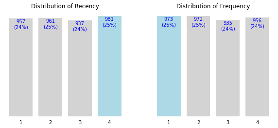

```python
# plot the distribution of customers over R and F
fig, axes = plt.subplots(nrows=1, ncols=2, figsize=(10, 4))

for i, p in enumerate(['R1', 'F1']):
    param = {'R1':'Recency', 'F1':'Frequency'}
    y = rfm[p].value_counts().sort_index()
    x = y.index
    ax = axes[i]
    bars = ax.bar(x, y, color='lightgray')
    ax.set_frame_on(False)
    ax.tick_params(left=False, labelleft=False, bottom=False)
    ax.set_title('Distribution of {}'.format(param[p]),
                fontsize=12)
    for bar in bars:
        value = bar.get_height()
        if value == y.max():
            bar.set_color('lightblue')
        ax.text(bar.get_x() + bar.get_width() / 2,
                value - 5,
                '{}\n({}%)'.format(int(value), int(value * 100 / y.sum())),
               ha='center',
               va='top',
               color='b')

plt.show()
```

```python
# count the number of customers in each segment
segments_counts = rfm['New Segment'].value_counts().sort_values(ascending=True)

segments_counts
```

```
Get Them back                  600
Champions                      762
Drifting Away or Freshers     1156
Will Leave                    1318
Name: New Segment, dtype: int64
```

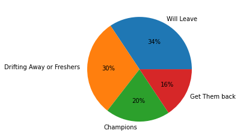

```python
plt.pie(rfm['New Segment'].value_counts(),
        labels=rfm['New Segment'].value_counts().index,
        autopct='%.0f%%')
plt.show()
```

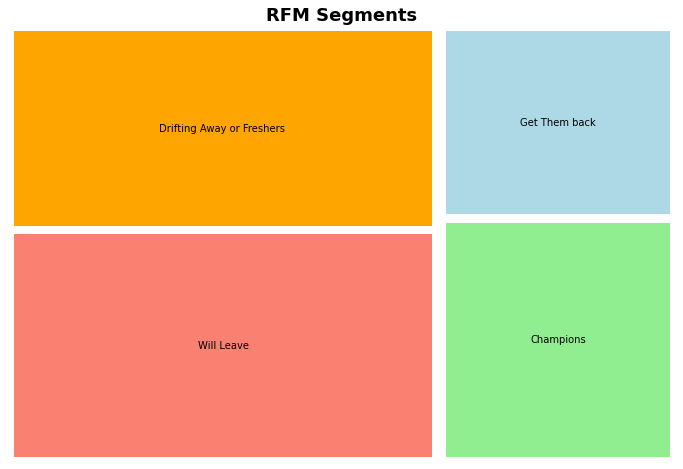

```python
#Create our RFM Segment plot and resize it.
#!pip install squarify
import squarify
fig = plt.gcf()
ax = fig.add_subplot()
fig.set_size_inches(12, 8)
#squarify.plot(sizes=rfm['monetary'],
              #label=rfm['Segment'], alpha=0.8 )
squarify.plot(rfm['New Segment'].value_counts(),label=rfm['New Segment'].value_counts().index,color=['salmon','orange','lightgreen','lightblue'], pad = True)
plt.title("RFM Segments",fontsize=18,fontweight="bold")
plt.axis('off')
plt.show()
```

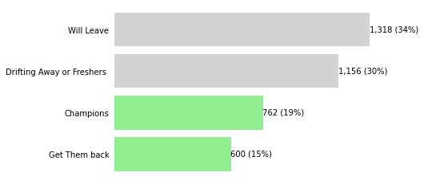

```python
# Distribution of Segments
fig, ax = plt.subplots()

bars = ax.barh(range(len(segments_counts)),
              segments_counts,
              color='lightgray')
ax.set_frame_on(False)
ax.tick_params(left=False,
               bottom=False,
               labelbottom=False)
ax.set_yticks(range(len(segments_counts)))
ax.set_yticklabels(segments_counts.index)

for i, bar in enumerate(bars):
        value = bar.get_width()
        if segments_counts.index[i] in ['Champions', 'Get Them back']:
            bar.set_color('lightgreen')
        ax.text(value,
                bar.get_y() + bar.get_height()/2,
                '{:,} ({:}%)'.format(int(value),
                                   int(value*100/segments_counts.sum())),
                va='center',
                ha='left'
               )

plt.show()
```

#### Q 15 (i) Comment on the above chart

#### Answer 15 (i)

Using 4 quanitles have shifted the percentage of many segments as following

- Likely to churn customers ("Will Leave") are the most at 34%, these are the customers that have low scores for recency and frequency.They made only few purchases long ago.(Recency 1-2 and frequency 1-2)
- Next in line are the customers either who have just joined us hence there frequency is really low but purchase was made a little time ago. 30% Customers are slowly drifting away they are buying perhaps seasonly, less frequent.
- Our regular champions are only 19%, these are our regular revenue generators.
- 15% are those used to buy frequently but haven't bought recently, so we should try and get them back.

#### Q 15 (ii) Who are the best customers?

#### Answer 15(ii)

```python
rfm[rfm['RFM Score']=='444'].sort_values('monetary', ascending=False).head()
```

| CustomerID | recency | frequency | monetary | R | F | M | RFM Score | Segment | R1 | F1 | M1 | RFM Score2 | New Segment |
| --- | --- | --- | --- | --- | --- | --- | --- | --- | --- | --- | --- | --- | --- |
| 17663.0 | 25 | 86 | 1802 | 4 | 4 | 4 | 444 | Loyal Customers | 3 | 3 | 4 | 334 | Drifting Away or Freshers |
| 15050.0 | 25 | 78 | 1782 | 4 | 4 | 4 | 444 | Loyal Customers | 3 | 3 | 4 | 334 | Drifting Away or Freshers |
| 13456.0 | 17 | 63 | 1766 | 4 | 4 | 4 | 444 | Loyal Customers | 4 | 3 | 4 | 434 | Drifting Away or Freshers |
| 15950.0 | 31 | 98 | 1765 | 4 | 4 | 4 | 444 | Loyal Customers | 3 | 4 | 4 | 344 | Champions |
| 14595.0 | 19 | 102 | 1740 | 4 | 4 | 4 | 444 | Loyal Customers | 3 | 4 | 4 | 344 | Champions |

#### Q 15 (iii) Which customers are likely to churn?

#### Answer 15 (iii)

```python
#Customers who's recency value is low

rfm[rfm['R1'] <= 1 ].sort_values('monetary', ascending=False).head()
```

| CustomerID | recency | frequency | monetary | R | F | M | RFM Score | Segment | R1 | F1 | M1 | RFM Score2 | New Segment |
| --- | --- | --- | --- | --- | --- | --- | --- | --- | --- | --- | --- | --- | --- |
| 13093.0 | 275 | 159 | 7832 | 1 | 5 | 5 | 155 | Can't loose | 1 | 4 | 4 | 144 | Get Them back |
| 12980.0 | 157 | 20 | 7374 | 2 | 2 | 5 | 225 | At risk | 1 | 2 | 4 | 124 | Will Leave |
| 16553.0 | 163 | 84 | 5719 | 2 | 4 | 5 | 245 | At risk | 1 | 3 | 4 | 134 | Get Them back |
| 17850.0 | 372 | 297 | 5391 | 1 | 5 | 5 | 155 | Can't loose | 1 | 4 | 4 | 144 | Get Them back |
| 15032.0 | 256 | 52 | 4959 | 1 | 3 | 5 | 135 | At risk | 1 | 3 | 4 | 134 | Get Them back |

#### Q 15 (iv) Which customers are we going to loose?

#### Answer 15 (iv)

Customers who are having low recency along with low frequnecy in past and low monetary value too are the customers that business will loose them. The poor RFM score of 111.

```python
rfm[rfm['RFM Score']=='111'].sort_values('recency',ascending=False).head()
```

| CustomerID | recency | frequency | monetary | R | F | M | RFM Score | Segment | R1 | F1 | M1 | RFM Score2 | New Segment |
| --- | --- | --- | --- | --- | --- | --- | --- | --- | --- | --- | --- | --- | --- |
| 14237.0 | 373 | 9 | 161 | 1 | 1 | 1 | 111 | At risk | 1 | 1 | 1 | 111 | Will Leave |
| 17643.0 | 373 | 8 | 101 | 1 | 1 | 1 | 111 | At risk | 1 | 1 | 1 | 111 | Will Leave |
| 15350.0 | 373 | 5 | 115 | 1 | 1 | 1 | 111 | At risk | 1 | 1 | 1 | 111 | Will Leave |
| 13747.0 | 373 | 1 | 79 | 1 | 1 | 1 | 111 | At risk | 1 | 1 | 1 | 111 | Will Leave |
| 15070.0 | 372 | 1 | 106 | 1 | 1 | 1 | 111 | At risk | 1 | 1 | 1 | 111 | Will Leave |

#### Q 15 (v) Who are the loyal customers?

#### Answer 15(v)

Regular Customers or Champions with the good RFM score (444) are the loyal customers. They buy regularly and frequently and monetary is moderate to high.

```python
rfm[rfm['F1'] >= 3 ].sort_values('monetary', ascending=False).head()
```

| CustomerID | recency | frequency | monetary | R | F | M | RFM Score | Segment | R1 | F1 | M1 | RFM Score2 | New Segment |
| --- | --- | --- | --- | --- | --- | --- | --- | --- | --- | --- | --- | --- | --- |
| 13001.0 | 4 | 339 | 9818 | 5 | 5 | 5 | 555 | Champions | 4 | 4 | 4 | 444 | Champions |
| 13199.0 | 3 | 119 | 9817 | 5 | 5 | 5 | 555 | Champions | 4 | 4 | 4 | 444 | Champions |
| 15078.0 | 7 | 440 | 9743 | 5 | 5 | 5 | 555 | Champions | 4 | 4 | 4 | 444 | Champions |
| 13458.0 | 7 | 382 | 9646 | 5 | 5 | 5 | 555 | Champions | 4 | 4 | 4 | 444 | Champions |
| 14733.0 | 16 | 202 | 9585 | 4 | 5 | 5 | 455 | Loyal Customers | 4 | 4 | 4 | 444 | Champions |

## RFM score & Segmentation with Modified RFM Dataset

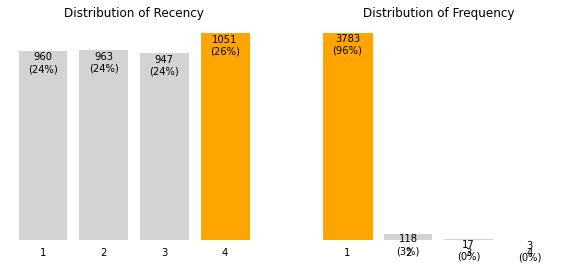

```python
# Using quintiles to make 4 equal parts based on the available values. Each quintile contains 25% of the population.
q1 = rfm1[['recency', 'frequency', 'monetary']].quantile([.25, .5, .75]).to_dict()

# Calculate RFM score for each customer
rfm1['R'] = rfm1['recency'].apply(lambda x: rscore(x))
rfm1['F'] = rfm1['frequency'].apply(lambda x: fmscore(x, 'frequency'))
rfm1['M'] = rfm1['monetary'].apply(lambda x: fmscore(x, 'monetary'))
rfm1['RFM Score'] = rfm1['R'].map(str) + rfm1['F'].map(str) + rfm1['M'].map(str)

# Create the customer segments based on your knowledge.
# Creating segments based on R and F scores

segments = {
     '[1-2][1-4]': 'Likely Churn',
     '3[1-3]': 'Drifting Away',
     '[2-4][3-4]': 'Regular Customers',
     '[3-4]1': 'New Customers',
     '[3-4][2-4]': 'Champions',
     '[1-2]5': 'should not loose',

    }

rfm1['Segment'] = rfm1['R'].map(str) + rfm1['F'].map(str)
rfm1['Segment'] = rfm1['Segment'].replace(segments, regex=True)

# plot the distribution of customers over R and F
fig, axes = plt.subplots(nrows=1, ncols=2, figsize=(10, 4))

for i, p in enumerate(['R', 'F']):
    param = {'R':'Recency', 'F':'Frequency'}
    y = rfm1[p].value_counts().sort_index()
    x = y.index
    ax = axes[i]
    bars = ax.bar(x, y, color='lightgray')
    ax.set_frame_on(False)
    ax.tick_params(left=False, labelleft=False, bottom=False)
    ax.set_title('Distribution of {}'.format(param[p]),
                fontsize=12)
    for bar in bars:
        value = bar.get_height()
        if value == y.max():
            bar.set_color('orange')
        ax.text(bar.get_x() + bar.get_width() / 2,
                value - 5,
                '{}\n({}%)'.format(int(value), int(value * 100 / y.sum())),
               ha='center',
               va='top',
               color='k')

plt.show()
```

```python
# count the number of customers in each segment
s_c = rfm1['Segment'].value_counts().sort_values(ascending=True)

s_c
```

```
Regular Customers      19
Champions             104
New Customers         928
Drifting Away         947
Likely Churn         1923
Name: Segment, dtype: int64
```

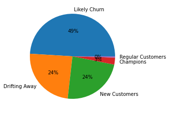

```python
plt.pie(rfm1['Segment'].value_counts(),
        labels=rfm1['Segment'].value_counts().index,
        autopct='%.0f%%')
plt.show()
```

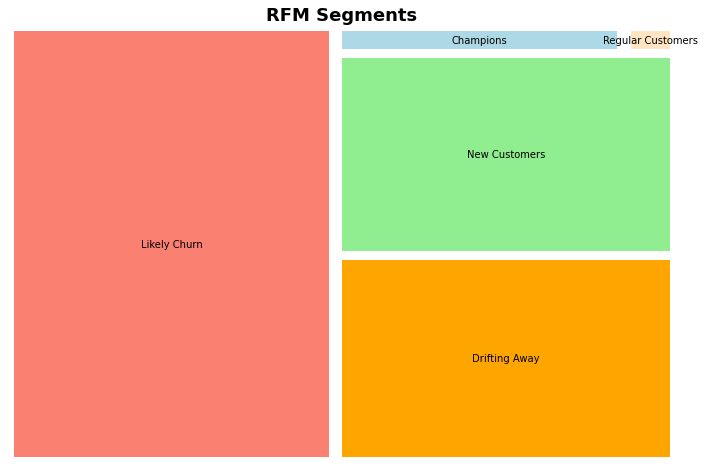

```python
#Create our RFM Segment plot and resize it.
#!pip install squarify
import squarify
fig = plt.gcf()
ax = fig.add_subplot()
fig.set_size_inches(12, 8)
#squarify.plot(sizes=rfm['monetary'],
              #label=rfm['Segment'], alpha=0.8 )
squarify.plot(rfm1['Segment'].value_counts(),label=rfm1['Segment'].value_counts().index,color=['salmon','orange','lightgreen','lightblue','bisque','rosybrown'], pad = True)
plt.title("RFM Segments",fontsize=18,fontweight="bold")
plt.axis('off')
plt.show()
```

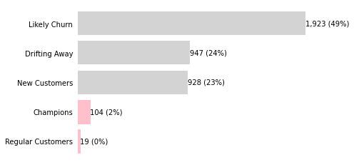

```python
# Distribution of Segments
fig, ax = plt.subplots()

bars = ax.barh(range(len(s_c)),
              s_c,
              color='lightgray')
ax.set_frame_on(False)
ax.tick_params(left=False,
               bottom=False,
               labelbottom=False)
ax.set_yticks(range(len(s_c)))
ax.set_yticklabels(s_c.index)

for i, bar in enumerate(bars):
        value = bar.get_width()
        if s_c.index[i] in ['Champions', 'Regular Customers']:
            bar.set_color('pink')
        ax.text(value,
                bar.get_y() + bar.get_height()/2,
                '{:,} ({:}%)'.format(int(value),
                                   int(value*100/s_c.sum())),
                va='center',
                ha='left'
               )

plt.show()
```

**This Graph suggests a differnt story, we have 49% customers who are liekly to churn with low recency and frequency scores. 24% are drifting away and 23% are new customers. The Champions are only 2%**

## Q16 Can you create segments based on F and M scores.

This is an extra exercise for groups who want to try more. It is not mandatory.

```python
# Create the customer segments based on your knowledge.
# Create 6 segments based on R and F scores

segmentsfm = {
    '[1-2][1-2]': 'Let them go',
    '[4-5][4-5]': 'Top Customers',
    '[3-4][3-5]': 'High Value',
    '[4-5][1-2]': 'Work on Them',
    '[1-3][1-4]': 'Lure Them'
    }

rfm['FM_Segment'] = rfm['F1'].map(str) + rfm['M1'].map(str)
rfm['FM_Segment'] = rfm['FM_Segment'].replace(segmentsfm, regex=True)
rfm.head()
```

| CustomerID | recency | frequency | monetary | R | F | M | RFM Score | Segment | R1 | F1 | M1 | RFM Score2 | New Segment | FM_Segment |
| --- | --- | --- | --- | --- | --- | --- | --- | --- | --- | --- | --- | --- | --- | --- |
| 13256.0 | 14 | 1 | 0 | 5 | 1 | 1 | 511 | New customers | 4 | 1 | 1 | 411 | Drifting Away or Freshers | Let them go |
| 16738.0 | 297 | 1 | 3 | 1 | 1 | 1 | 111 | At risk | 1 | 1 | 1 | 111 | Will Leave | Let them go |
| 16454.0 | 44 | 2 | 6 | 3 | 1 | 1 | 311 | Needs Attention | 3 | 1 | 1 | 311 | Drifting Away or Freshers | Let them go |
| 14792.0 | 63 | 2 | 6 | 3 | 1 | 1 | 311 | Needs Attention | 2 | 1 | 1 | 211 | Will Leave | Let them go |
| 17956.0 | 249 | 1 | 12 | 1 | 1 | 1 | 111 | At risk | 1 | 1 | 1 | 111 | Will Leave | Let them go |

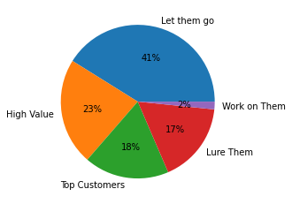

```python
plt.pie(rfm['FM_Segment'].value_counts(),
        labels=rfm['FM_Segment'].value_counts().index,
        autopct='%.0f%%')
plt.show()
```

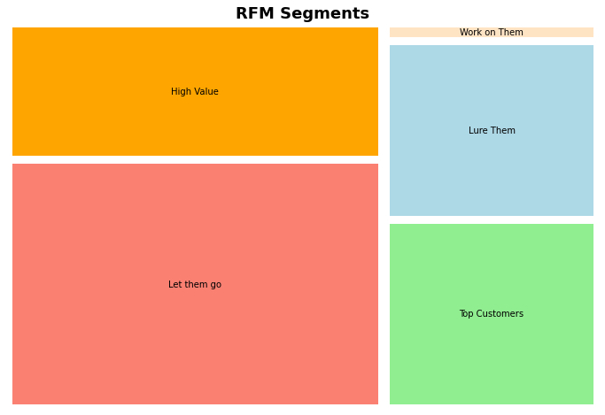

```python
#Create our RFM Segment plot and resize it.
#!pip install squarify
import squarify
fig = plt.gcf()
ax = fig.add_subplot()
fig.set_size_inches(12, 8)
#squarify.plot(sizes=rfm['monetary'],
              #label=rfm['Segment'], alpha=0.8 )
squarify.plot(rfm['FM_Segment'].value_counts(),label=rfm['FM_Segment'].value_counts().index,color=['salmon','orange','lightgreen','lightblue','bisque','rosybrown'], pad = True)
plt.title("RFM Segments",fontsize=18,fontweight="bold")
plt.axis('off')
plt.show()
```

## Customer Segmentation Analysis Part 2

```python
# Import the appropriate Libraries
import pandas as pd # for dataframes
import matplotlib.pyplot as plt # for plotting graphs
import seaborn as sns # for plotting graphs
import datetime as dt
import numpy as np
```

```python
# Load rfm data from Part 1
rfm = pd.read_csv('/content/drive/MyDrive/Colab Notebooks/rfm.csv', index_col ='CustomerID')
```

```python
rfm.head()
```

| CustomerID | recency | frequency | monetary |
| --- | --- | --- | --- |
| 13256.0 | 14 | 1 | 0 |
| 16738.0 | 297 | 1 | 3 |
| 16454.0 | 44 | 2 | 6 |
| 14792.0 | 63 | 2 | 6 |
| 17956.0 | 249 | 1 | 12 |

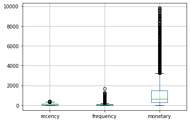

```python
# Create box plots to check for outliers
rfm.boxplot()
```

```python
# Calculate Z scores to normalize the data
from scipy import stats
import numpy as np
z = np.abs(stats.zscore(rfm))
print(z)
```

```
[[0.79548532 0.66779943 0.80336162]
 [2.04159154 0.66779943 0.80133672]
 [0.49473512 0.65921664 0.79931182]
 ...
 [0.86566036 3.10004395 5.77283257]
 [0.90576039 0.34496941 5.82278006]
 [0.89573538 2.23318249 5.82345502]]
```

```python
rfm_clean = rfm[(z < 3).all(axis=1)]
```

### Q 20. What is the purpose of the above code

### Answer 20

In order to compare data the above code calculated z score to normalize the data, rfm_clean dataset contains all the values with z score less than 3. The values more than 3 z score are three standard deviations away from central tendency and are unlikely to represent the data. The purpose is to eliminate z values that are beyond the threshold limit. The potential outliers will be eliminated as we shoud not consider them in analysis.

```python
rfm.shape
```

```
(3836, 3)
```

```python
rfm_clean.shape
```

```
(3683, 3)
```

#### Q 21. Create box plot to check for outliers with the cleaned data and comment on it. Compare it with the previous box plot.

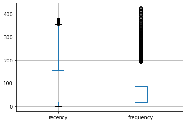

```python
rfm_clean[rfm_clean.columns[0:2]].boxplot()
```

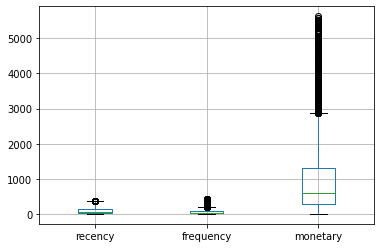

```python
rfm_clean.boxplot()
```

### Q 22. Create the Histogram for R, F, and M for the cleaned data. Comment on them and compare them with the previous histograms

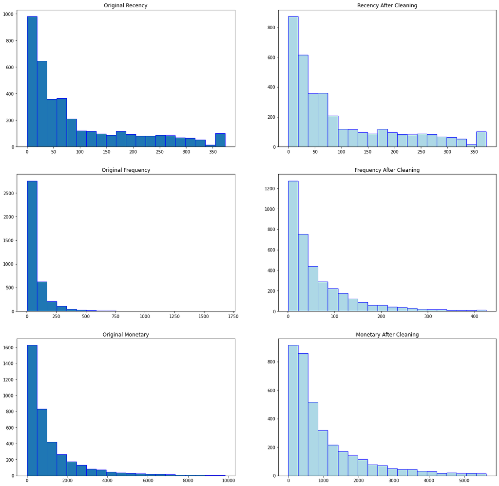

```python
fig, axes = plt.subplots(nrows=3, ncols=2, figsize=(20, 20))

axes[0,0].hist(rfm['recency'], bins=20,edgecolor='blue')
axes[0,0].set_title('Original Recency')
axes[0,1].hist(rfm_clean['recency'],bins=20,color="lightblue",edgecolor='blue')
axes[0,1].set_title('Recency After Cleaning')
axes[1,0].hist(rfm['frequency'], bins=20,edgecolor='blue')
axes[1,0].set_title('Original Frequency')
axes[1,1].hist(rfm_clean['frequency'],bins=20,color="lightblue",edgecolor='blue')
axes[1,1].set_title('Frequency After Cleaning')
axes[2,0].hist(rfm['monetary'], bins=20,edgecolor='blue')
axes[2,0].set_title('Original Monetary')
axes[2,1].hist(rfm_clean['monetary'],bins=20,color="lightblue",edgecolor='blue')
axes[2,1].set_title('Monetary After Cleaning')

plt.show()
```

#### Answer 22 Comparison

All the histograms have a right skewed distribution.

The data representation is realistic and comrehensive for further analaysis.

## 23 Perform cluster analysis using K-means clustering with the original rfm dataframe

```python
X = rfm
```

```python
X.head()
```

| CustomerID | recency | frequency | monetary |
| --- | --- | --- | --- |
| 13256.0 | 14 | 1 | 0 |
| 16738.0 | 297 | 1 | 3 |
| 16454.0 | 44 | 2 | 6 |
| 14792.0 | 63 | 2 | 6 |
| 17956.0 | 249 | 1 | 12 |

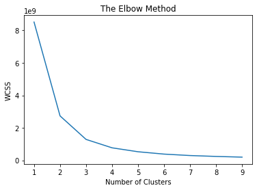

```python
# Choose number of Clusters using the elbow method
# Within cluster sum of squares (wcss)
from sklearn.cluster import KMeans
# start with 10 number of clusters
wcss = []
for i in range(1,10):
    kmeans = KMeans(n_clusters =i, init = 'k-means++', max_iter =300, n_init =10, random_state =0)
    kmeans.fit(X)
    wcss.append(kmeans.inertia_)
plt.plot(range(1,10), wcss)
plt.title('The Elbow Method')
plt.xlabel('Number of Clusters')
plt.ylabel('WCSS')
plt.show()
```

```python
# Fitting K Means to the Datatset using k = 3
kmeans = KMeans(n_clusters = 3)
y_kmeans = kmeans.fit_predict(X)
```

```python
y_kmeans
```

```
array([0, 0, 0, ..., 2, 2, 2], dtype=int32)
```

```python
# Adding cluster ID to the dataframe
rfm['Cluster_ID'] = y_kmeans
```

```python
rfm.head()
```

| CustomerID | recency | frequency | monetary | Cluster_ID |
| --- | --- | --- | --- | --- |
| 13256.0 | 14 | 1 | 0 | 0 |
| 16738.0 | 297 | 1 | 3 | 0 |
| 16454.0 | 44 | 2 | 6 | 0 |
| 14792.0 | 63 | 2 | 6 | 0 |
| 17956.0 | 249 | 1 | 12 | 0 |